# Practical Machine Learning Course Project

Matthew Jorden

5/20/2017

The purpose of this exercise is to predict quality of exercise based on given classes from fitness devices. A testing set (with class labels) and a training set has been provided. From the training set, I intend to create a model which can correctly predict the classes on the testing set.

First things first, I need to load the packages `caret`, `readr`, `rpart`, `ggplot2` and `randomForest` as well as set a seed for reproducibility.

```r
library(caret)
library(readr)
library(rpart)
library(ggplot2)
library(randomForest)
set.seed(4345)
```

## Loading & Cleaning Data

Both data sets were downloaded from the URL provided by the Coursera course. I download both and read them into a train & a test set.

There are many variables in the data, most of which may not be useful or may not contain complete records. To account for this, I remove columns with NA values. I accomplish this by creating a list of columns that contain NA values, and remove these columns from both the training & testing data sets.

Next, I need to separate the training data itself into a training and testing set for validaton & checking in-sample and out of sample errors. I am placing 70% of the data into the training set, and retaining 30% to test the models.

```r
train <- read_csv("https://d396qusza40orc.cloudfront.net/predmachlearn/pml-training.csv")
test <- read_csv("https://d396qusza40orc.cloudfront.net/predmachlearn/pml-testing.csv")

NAcolumns <- colMeans(is.na(train))
train <- train[, !NAcolumns]
train <- train[, -c(1:5)]
test <- test[, !NAcolumns]
test <- test[, -c(1:5)]

inTrain <- createDataPartition(y = train$classe, p = 0.7, list = FALSE)
training <- train[inTrain,]
testing <- train[-inTrain,]
```

## Creating Models

I am going to run two models, one using the rpart method and one using random forest. Fair warning if you run this at home: The rpart runs quickly, but the random forest method takes significant time & resources to complete.

### RPart Model

The RPart model is generated by calling the `caret` command `train()`.

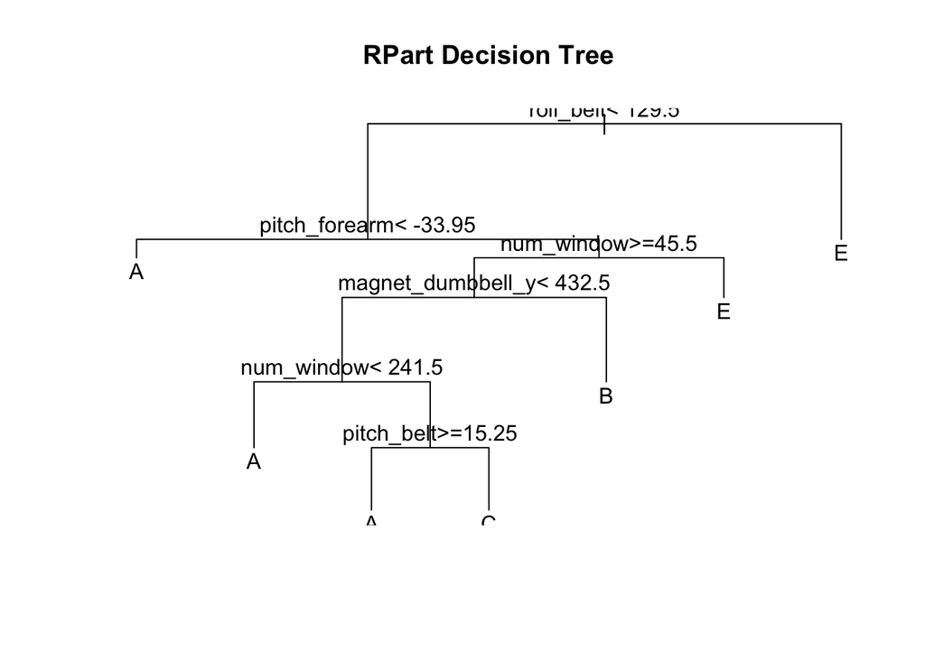

```r
modRPart <- train(classe ~ ., data = training, method = "rpart")
#print(modRPart$finalModel)
plot(modRPart$finalModel, main = "RPart Decision Tree")
text(modRPart$finalModel)
```

I then predict values for both the training & testing data sets.

```r
predRpart <- predict(modRPart, training)
predRpart2 <- predict(modRPart, testing)
```

Lets first take a look at the results from the predicted classed on the training set.

```r
confmax <- confusionMatrix(training$classe, predRpart)
print(confmax$table)
```

```
##           Reference
## Prediction    A    B    C    D    E
##          A 3068   74  715    0   49
##          B  483  912 1263    0    0
##          C  329   80 1987    0    0
##          D  333  400 1422    0   97
##          E   67  184  682    0 1592
```

```r
print(confmax$overall)
```

```
##       Accuracy          Kappa  AccuracyLower  AccuracyUpper   AccuracyNull
##   5.502657e-01   4.291650e-01   5.419005e-01   5.586096e-01   4.417995e-01
## AccuracyPValue  McnemarPValue
##  1.840235e-143   0.000000e+00
```

The overall accuracy for the RPart model is 0.5502657.

```r
confmax2 <- confusionMatrix(testing$classe, predRpart2)
print(confmax2$table)
```

```
##           Reference
## Prediction    A    B    C    D    E
##          A 1310   33  306    0   25
##          B  216  408  515    0    0
##          C  170   35  821    0    0
##          D  147  199  569    0   49
##          E   27   77  298    0  680
```

```r
print(confmax2$overall)
```

```
##       Accuracy          Kappa  AccuracyLower  AccuracyUpper   AccuracyNull
##   5.469839e-01   4.243740e-01   5.341602e-01   5.597609e-01   4.263381e-01
## AccuracyPValue  McnemarPValue
##   2.816297e-77   0.000000e+00
```

Given that our accuracies here are 0.5502657 and 0.5469839 are slightly above 0.5, I propose we abandon the RPart model. Instead of a single tree like rpart creates, lets move to a random forest approach.

### Random Forest

Since Rpart did not give us a satisfactory solution, I will try a random forest model. I warn users that this takes some time & computational resources to complete.

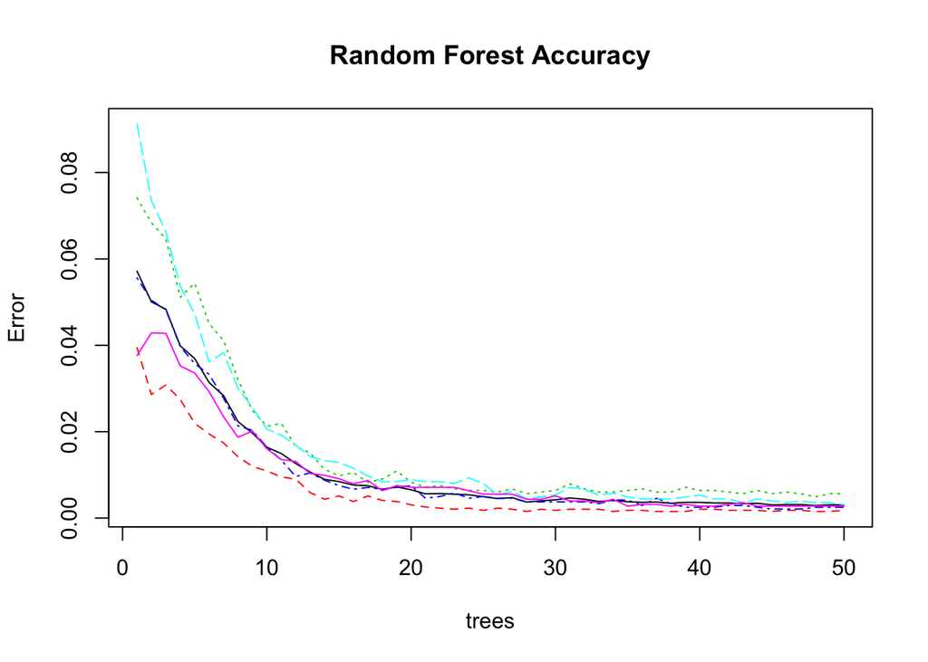

```r
modRF <- train(classe ~ ., data= training, method="rf", ntree = 50)
plot(modRF$finalModel, main = "Random Forest Accuracy")
```

The above plot shows accuracy as additional trees are added to the forest. It appears that a 50 tree model is eliminating most error.

Lets also take a look at which variables are considered important predictors:

```r
varImp(modRF)
```

```
## rf variable importance
##
##   only 20 most important variables shown (out of 51)
##
##                      Overall
## num_window           100.000
## roll_belt             66.713
## pitch_forearm         43.333
## pitch_belt            33.904
## yaw_belt              33.344
## roll_forearm          30.882
## magnet_dumbbell_y     28.696
## accel_dumbbell_y      15.239
## magnet_dumbbell_x     14.935
## roll_dumbbell         10.999
## accel_forearm_x       10.861
## magnet_belt_z         10.519
## accel_forearm_z        9.641
## magnet_belt_y          9.258
## accel_belt_z           9.220
## accel_dumbbell_z       8.905
## total_accel_dumbbell   8.778
## accel_dumbbell_x       7.464
## magnet_belt_x          7.312
## yaw_dumbbell           6.544
```

The relevant predictors are quite similar to the previous tree created with `rpart`. The advantage with the `random forest` approach is the multiple trees averaging towards an outcome.

```r
predRF1 <- predict(modRF, training)
confmax3 <- confusionMatrix(training$classe, predRF1)
print(confmax3$table)
```

```
##           Reference
## Prediction    A    B    C    D    E
##          A 3906    0    0    0    0
##          B    0 2658    0    0    0
##          C    0    0 2396    0    0
##          D    0    0    0 2252    0
##          E    0    0    0    0 2525
```

The table shows that within our training data, the model has correctly predicted every single point. The resulting model accuracy is 1

```r
predRF2 <- predict(modRF, testing)
confmax4 <- confusionMatrix(testing$classe, predRF2)
print(confmax4$table)
```

```
##           Reference
## Prediction    A    B    C    D    E
##          A 1673    0    0    0    1
##          B    3 1136    0    0    0
##          C    0    0 1026    0    0
##          D    0    0    6  955    3
##          E    0    0    0    5 1077
```

- The in sample error rate is 0%
- The out of sample error rate is 0.3058624%

Comparing the Random Forest accuracies of 1 / 0.9969414 to the RPart accuracies of 0.5502657 / 0.5469839, we can clearly see that Random Forest is the correct choice for the model.

## Final Prediction

Now that I have chosen the final model, I just need to apply it to the test data and determine final predicted classes.

```r
finalpred <- predict(modRF, test)
```

I am not showing the results, but when I completed the Coursera quiz I received a grade of 100%. The models accuracy is 100%, or close to it.